# Reproducible Research Course Project Week 2

Aixa Rodriguez Salan

3 de diciembre de 2016

## Loading and preprocessing the data

First the data was download from url [Activity monitoring data](https://d396qusza40orc.cloudfront.net/repdata%2Fdata%2Factivity.zip) and read the csv data file from the zip file and transform the date into a readable format for analysis.

```r
download.file("https://d396qusza40orc.cloudfront.net/repdata%2Fdata%2Factivity.zip","activity.zip")
activity_read<-read.csv(unz("activity.zip","activity.csv"),header=TRUE,sep=",")
activity_read$date<-as.Date(activity_read$date)

summary(activity_read)
```

```
##      steps             date               interval
##  Min.   :  0.00   Min.   :2012-10-01   Min.   :   0.0
##  1st Qu.:  0.00   1st Qu.:2012-10-16   1st Qu.: 588.8
##  Median :  0.00   Median :2012-10-31   Median :1177.5
##  Mean   : 37.38   Mean   :2012-10-31   Mean   :1177.5
##  3rd Qu.: 12.00   3rd Qu.:2012-11-15   3rd Qu.:1766.2
##  Max.   :806.00   Max.   :2012-11-30   Max.   :2355.0
##  NA's   :2304
```

```r
head(activity_read)
```

```
##   steps       date interval
## 1    NA 2012-10-01        0
## 2    NA 2012-10-01        5
## 3    NA 2012-10-01       10
## 4    NA 2012-10-01       15
## 5    NA 2012-10-01       20
## 6    NA 2012-10-01       25
```

Two dataset are defined, activity_read with the original data and activity_data a subset without missing values.

```r
activity_data<-subset(activity_read,!is.na(activity_read$steps))

summary(activity_data)
```

```
##      steps             date               interval
##  Min.   :  0.00   Min.   :2012-10-02   Min.   :   0.0
##  1st Qu.:  0.00   1st Qu.:2012-10-16   1st Qu.: 588.8
##  Median :  0.00   Median :2012-10-29   Median :1177.5
##  Mean   : 37.38   Mean   :2012-10-30   Mean   :1177.5
##  3rd Qu.: 12.00   3rd Qu.:2012-11-16   3rd Qu.:1766.2
##  Max.   :806.00   Max.   :2012-11-29   Max.   :2355.0
```

```r
head(activity_data)
```

```
##     steps       date interval
## 289     0 2012-10-02        0
## 290     0 2012-10-02        5
## 291     0 2012-10-02       10
## 292     0 2012-10-02       15
## 293     0 2012-10-02       20
## 294     0 2012-10-02       25
```

## What is mean total number of steps taken per day?

First calculate the total number of steps by day.

```r
steps_by_day<-aggregate(activity_data$steps,list(activity_data$date),sum)
```

Plotting the histogram for the result of the total number of steps taken each day.

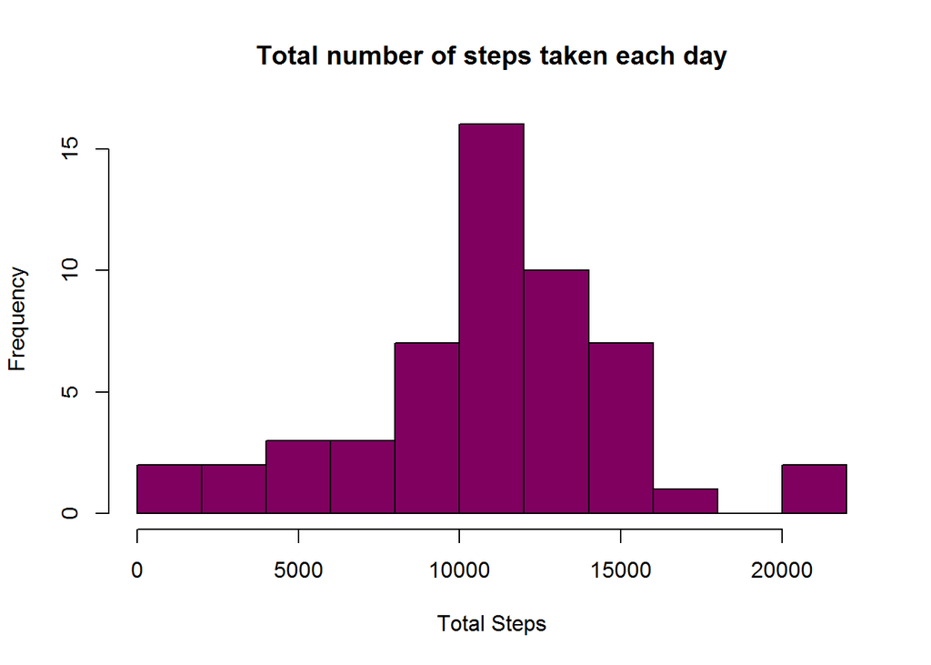

And finally calculate the mean and median of the number of steps taken by day.

```r
#Mean:
mean(steps_by_day$x)
```

```
## [1] 10766.19
```

```r
#Median:
median(steps_by_day$x)
```

```
## [1] 10765
```

## What is the average daily activity pattern?

First calculate the mean for each time interval.

```r
steps_by_5min<-aggregate(activity_data$steps,list(activity_data$interval),mean)
```

Plot the time series of the 5-minute interval and the average number of steps taken across all days.

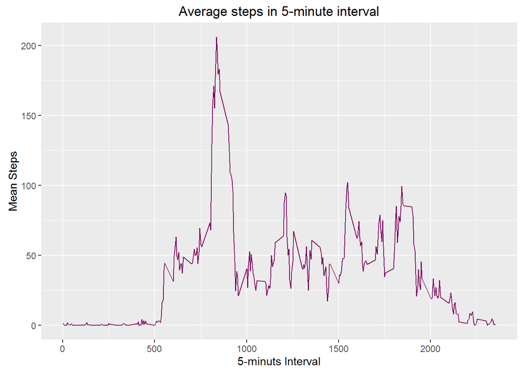

The 5-minute interval that contains the maximum number of steps is

```r
#Interval:
steps_by_5min[with(steps_by_5min,x==max(steps_by_5min$x)),]$Group.1
```

```
## [1] 835
```

And the max average it’s

```r
#Max:
max(steps_by_5min$x)
```

```
## [1] 206.1698
```

## Imputing missing values

The total number of missing values in the dataset are

```r
#Total:
nrow(activity_read)-nrow(activity_data)
```

```
## [1] 2304
```

Filling all the missing data with the mean of the interval

```r
activity_read$mean<-tapply(activity_data$steps,activity_data$interval,mean)
activity_read$steps[is.na(activity_read$steps)]<-activity_read$mean[is.na(activity_read$steps)]
activity_fill<-activity_read[,c("steps","interval","date")]
```

With the new dataset filled first calculate the number of steps by day.

```r
steps_by_fillday<-aggregate(activity_fill$steps,list(activity_fill$date),sum)
```

Plot the histogram of the total number of steps taken each day using filled dataset.

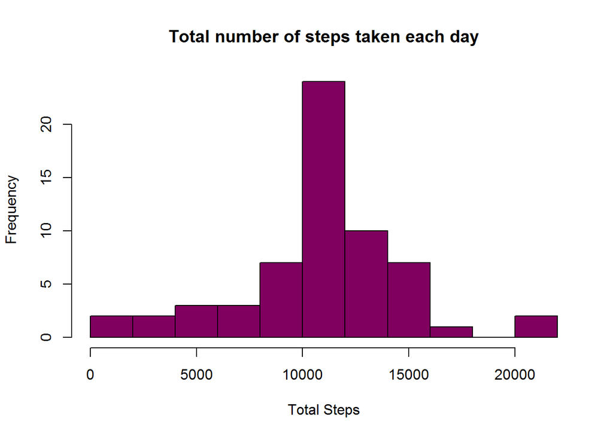

And finally calculate the mean and median of the number of steps taken by day with the filled dataset.

```r
#Mean:
mean(steps_by_fillday$x)
```

```
## [1] 10766.19
```

```r
#Median:
median(steps_by_fillday$x)
```

```
## [1] 10766.19
```

Comparing the 10,766.19 (mean) and 10,765 (median) that we get from the first dataset excluding missing data and the 10,766.19 (mean) and 10,766.19 (median) from imputing missing data on estimates of total intervals of steps the difference between both are minimal and has not impact.

## Are there differences in activity patterns between weekdays and weekends?

First add the new columns to know if the days are weekdays or weekend

```r
activity_fill$weekday<-"weekday";
activity_fill$weekday[grep("domingo|sábado|sunday|saturday",weekdays(activity_fill$date))]<-"weekend";
activity_fill$weekday<-as.factor(activity_fill$weekday)
```

Calculating the mean of the data by type of day and 5-min interval

```r
activity_week_mean<-aggregate(steps~weekday+interval,data=activity_fill,FUN=mean)
```

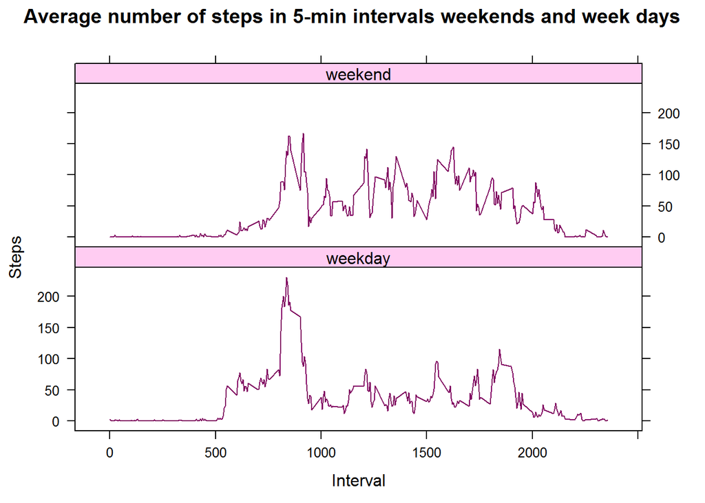